# Exploring the BRFSS data

What is the trend of people exercising against different obesity levels ? Lets check out the ‘exerany2’ variable against the ‘X_bmi5cat’ variable.

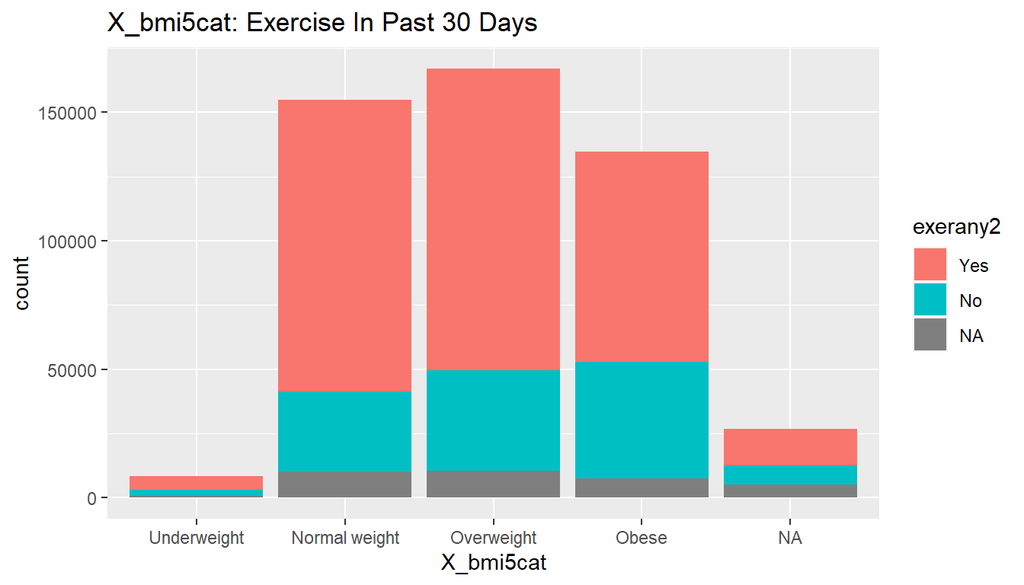

```r
# X_bmi5cat: Computed Body Mass Index Categories
# exerany2: Exercise In Past 30 Days

ggplot(data=df, aes(x = X_bmi5cat, fill = exerany2)) +
  geom_bar() +
  labs(title="X_bmi5cat: Exercise In Past 30 Days")
```

As the count figure is high into the 150K range, we might not be able to see a good picture of the plot. Lets do another plot in terms of ratio of “Yes’ and”No". Some rearranging and consolidating work below on ‘exerany2’ yes/no data.

```r
df2b <-df %>%
  group_by(X_bmi5cat,exerany2) %>%
  count()

df2b
```

```
## # A tibble: 15 x 3
## # Groups:   X_bmi5cat, exerany2 [15]
##    X_bmi5cat     exerany2      n
##    <fct>         <fct>     <int>
##  1 Underweight   Yes        5159
##  2 Underweight   No         2497
##  3 Underweight   <NA>        611
##  4 Normal weight Yes      113554
##  5 Normal weight No        31113
##  6 Normal weight <NA>      10231
##  7 Overweight    Yes      117537
##  8 Overweight    No        38950
##  9 Overweight    <NA>      10597
## 10 Obese         Yes       81882
## 11 Obese         No        45306
## 12 Obese         <NA>       7611
## 13 <NA>          Yes       14332
## 14 <NA>          No         7416
## 15 <NA>          <NA>       4977
```

```r
# Consolidate all the "Yes" into one column, and all the "No" in another column.

yesExer <- df2b %>% filter(exerany2 == "Yes") %>% rename(yesExercise = n)
yesExer <- yesExer[,-c(2)] # Remove unwanted column

noExer <-df2b %>% filter(exerany2 == "No") %>% rename(noExercise = n)


exerYesNo <- cbind(yesExer,
                 noExercise = noExer$noExercise,
                 ratioYesNo = yesExer$yesExercise/(yesExer$yesExercise + noExer$noExercise))
exerYesNo
```

```
## # A tibble: 5 x 4
## # Groups:   X_bmi5cat [5]
##   X_bmi5cat     yesExercise noExercise ratioYesNo
##   <fct>               <int>      <int>      <dbl>
## 1 Underweight          5159       2497      0.674
## 2 Normal weight      113554      31113      0.785
## 3 Overweight         117537      38950      0.751
## 4 Obese               81882      45306      0.644
## 5 <NA>                14332       7416      0.659
```

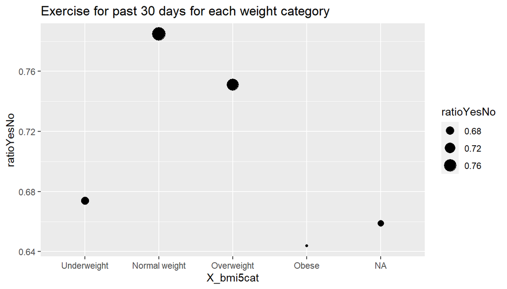

```r
ggplot(data=exerYesNo, aes(x = X_bmi5cat, y=ratioYesNo)) +
  geom_point(aes(size=ratioYesNo)) +
  labs(title='Exercise for past 30 days for each weight category')
```

Above plot shows as people get more obese, the lesser frequency they do exercises. As for the ’Underweight’category, I suspect a number these group of people might have some health problems, resulting in low exercise take-up rate.

Conclusion: Overweight has close relationship with heart attack as shown on plotted chart. The more obese, the higher chance of getting heart attack. Conversely, overweight people tend not to do exercises regularly. And the more overweight, the less likely these group of obese people do exercises regularly.

**Research quesion 3:** Does low income level affect people from getting healthcare covreage? Does low income level restrict people from getting proper medications?

```r
df %>% group_by(income2) %>% summarise(n())
```

```
## # A tibble: 9 x 2
##   income2            `n()`
##   <fct>              <int>
## 1 Less than $10,000  25441
## 2 Less than $15,000  26794
## 3 Less than $20,000  34873
## 4 Less than $25,000  41732
## 5 Less than $35,000  48867
## 6 Less than $50,000  61509
## 7 Less than $75,000  65231
## 8 $75,000 or more   115902
## 9 <NA>               71424
```

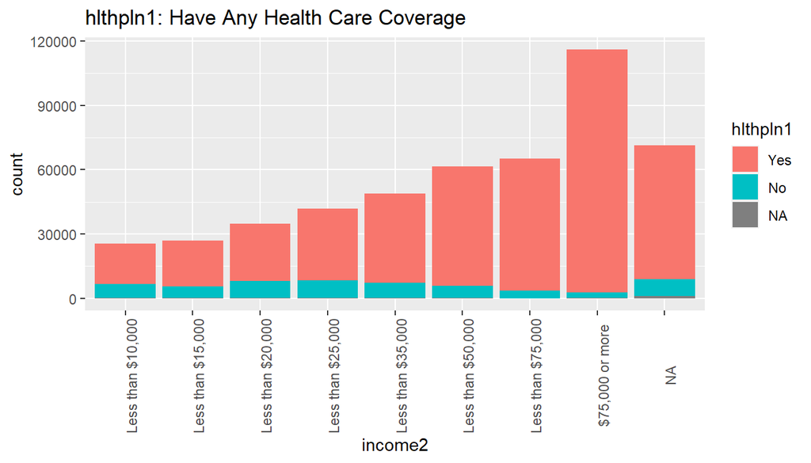

```r
# hlthpln1: Have Any Health Care Coverage
ggplot(data=df, aes(x = income2, fill = hlthpln1)) +
  geom_bar() +
  theme(axis.text.x = element_text(angle=90)) +
  labs(title = "hlthpln1: Have Any Health Care Coverage")
```

This plot shows lower income level does affect people from getting healthcare coverage.

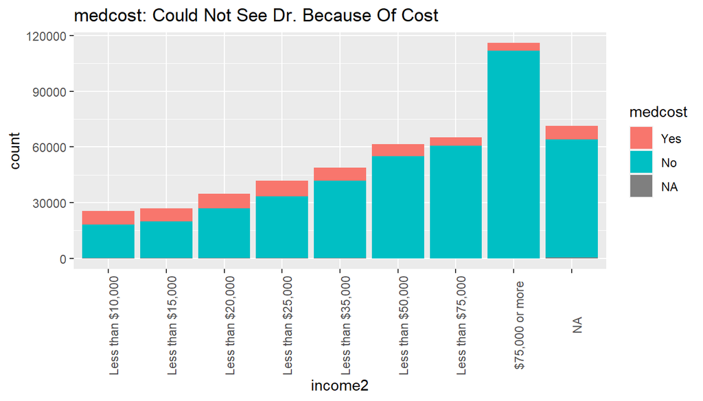

```r
# medcost: Could Not See Dr. Because Of Cost

ggplot(data=df, aes(x = income2, fill = medcost)) +
  geom_bar() +
  theme(axis.text.x = element_text(angle=90)) +
  labs(title = "medcost: Could Not See Dr. Because Of Cost")
```

This plot shows lower income level also caused people to access medication.

Conclusion: Lower income level does affect people from getting healthcare coverage as shown on plotted bar chart. Lower income people also have issues seeing doctors.